# Rtutorial_week3

Ji-Hye Choi  
2017.05.17

### Review week2 (1): ExpressionSet

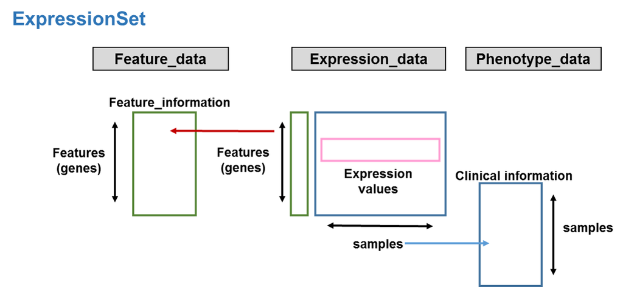

### Review week2 (1): ExpressionSet

1. Read cufflinks output files of each sample
2. Make data
   - Expression data: FPKM matrix (gene by sample)
   - Feature data: Gene info data.frame
   - Phenotype data: Sample info data.frame
3. ExpressionSet(Expression, Phenotype, Feature)

### Review week2 (2): DEG and GO analysis

1. preprocess eset
   - log2
   - aggregation (gene symbol)
2. Identify DEG
   - mean of groups (T, N)
   - fold change (mean.T - mean.N)
   - Up/Down DEG by fold change cutoff
3. GO analysis
   - ligrary(gProfileR)

### TODAY

- Load expression set
- Identify up/down DEG (Tumor vs Normal)
- GO using DAVID software
- Network (GENEMANIA)
- Gene set enrichment analysis (GSEA)
- IGV

### Web-based analysis tools

- GO analysis: DAVID (https://david.ncifcrf.gov/home.jsp)
  - Functional Annotation Chart: Fisher's Exact Test (P-value)
  - Functional Annotation Clustering: Fuzzy clustering
- Network analysis: GENEMANIA (http://genemania.org/)
  - Physical interection
  - Genetic interection
  - Pathway interection
  - …

### GSEA analysis

- Group comparision (e.g., T vs N)
  - GSEA java program or R function, genepattern (https://genepattern.broadinstitute.org/gp)
  - input files: expression (.gct), geneset signature (.gmt), class (.cls)
  - http://software.broadinstitute.org/cancer/software/genepattern/file-formats-guide
  - permutation type: gene_set
  - collapse dataset: false

### GSEA input in R

- .gct file (remove NA value)

```
fn=file.path(getwd(), "result/expr.gct")
cat("#1.2\n", file=fn)
cat(c(nrow(fil.eset),"\t",ncol(fil.eset),"\n"), sep="", file=fn, append=T)
res=cbind(as.data.frame(rownames(fil.eset)), rownames(fil.eset), exprs(fil.eset))
colnames(res)[1:2]=c("NAME", "DESCRIPTION")
write.table(res, file=fn, append=T, sep="\t", quote=F, row.names=F, col.names=T)
```

### GSEA input in R

- .cls

```
fn=file.path(getwd(), "result/TvsN.cls")
pData(fil.eset)$class=factor(c("T","T","T","N","N","N"), levels=c("T","N"))
n.cls=names(table(pData(fil.eset)$class))
cat(paste(length(pData(fil.eset)$class),length(n.cls),"1",sep=" "),"\n", file=fn)
cat("#", file=fn, append=T)
cat(paste(n.cls,sep=" "),"\n", file=fn, append=T)
cat(paste(pData(fil.eset)$class,sep=" "),"\n", file=fn,append=T)
```

### GSEA input in R

- .gmt

```
for (i in 1:length(siglist)){
  cat(names(siglist[i]), "NA", siglist[[i]],"\n",append=T, sep="\t",file=fn)
}
```

### IGV

http://software.broadinstitute.org/software/igv/

[figure not shown]

### Next

- GRange, getSequence
- Sequence enrichment
- RMarkdown
- ggplot

### Project

- Samples
  - Control: HepG2
  - wtSF3B3: SF3B3 overexpression in HepG2
  - mutSF3B3: mutant form SF3B3 overexpression in HepG2
- Phenotype
  - Contrl: liver cancer
  - wtSF3B3: proliferation, migration, invasion (+)
  - mutSF3B3: proliferation, migration, invasion (++)
  - previous study: https://www.ncbi.nlm.nih.gov/pubmed/28038442